# Análisis Descriptivo de los Factores Determinantes en el Precio de la Vivienda

Un Estudio de Caso en el Estado de Washington (2014)

2025-09-28

# Planteamiento de la Investigación

## 1. Planteamiento del Problema

El mercado inmobiliario es uno de los pilares de la economía y un reflejo de la salud socioeconómica de una región. El precio de una vivienda es una variable compleja, influenciada por una multitud de factores intrínsecos (como el tamaño, el número de habitaciones o el estado de conservación) y extrínsecos (como la ubicación o la proximidad a servicios). Para compradores, vendedores, inversores y agentes inmobiliarios, la capacidad de comprender qué características tienen un mayor impacto en el valor de una propiedad es fundamental para la toma de decisiones informadas.

Este estudio aborda la necesidad de cuantificar y describir las relaciones entre las características de las viviendas y sus precios de venta en el mercado del estado de Washington, con el fin de identificar los patrones que definen el valor inmobiliario en esta región.

## 2. Objetivos

### 2.1. Objetivo General

Realizar un análisis estadístico descriptivo de los datos de precios de viviendas en el estado de Washington para identificar y describir las características más influyentes en la valoración de las propiedades durante el período de estudio.

### 2.2. Objetivos Específicos

# Marco de Referencia

## 3. Marco Teórico

Este estudio se apoya en la **estadística descriptiva** para resumir y organizar los datos de manera informativa. Se emplean **medidas de tendencia central** (media, mediana) para determinar el “precio típico” y **medidas de dispersión** (desviación estándar) para entender la variabilidad de los precios.

El análisis de relaciones entre variables se aborda mediante **visualizaciones de datos**, como **diagramas de dispersión** (scatter plots) para explorar la correlación entre variables continuas (ej. precio vs. superficie) y **diagramas de caja** (box plots) para comparar distribuciones de precios entre categorías (ej. por número de habitaciones). Estos métodos permiten identificar tendencias y patrones de forma visual y efectiva, sentando las bases para modelos de valoración inmobiliaria más complejos.

## 4. Marco Metodológico

### 4.1. Enfoque y Tipo de Investigación

La investigación adopta un **enfoque cuantitativo** de tipo **descriptivo-correlacional**. No solo busca describir las variables de forma aislada, sino también explorar la existencia y la forma de las relaciones entre ellas, sin llegar a establecer inferencias de causalidad.

### 4.2. Fuente de Datos

Se utiliza el conjunto de datos `data_house_price.csv`, que contiene registros de ventas de viviendas. Las variables clave para este análisis son: `price`, `bedrooms`, `bathrooms`, `sqft_living`, `sqft_lot`, `floors`, `condition`, `yr_built`, y `city`.

### 4.3. Período de Referencia

El conjunto de datos registra transacciones ocurridas principalmente durante el año **2014**.

### 4.4. Procesamiento y Análisis de Datos

El análisis se realiza con **R** y las librerías `dplyr` y `ggplot2`. El proceso consta de: 1. **Limpieza de Datos:** Carga del dataset, manejo de valores atípicos o no válidos (ej. precios en cero, número de habitaciones irreal), y corrección de tipos de datos. 2. **Análisis Descriptivo:** Cálculo de estadísticas resumen. 3. **Visualización:** Creación de gráficos para ilustrar distribuciones y relaciones. Se utiliza una paleta de colores consistente inspirada en “La noche estrellada”. 4. **Tabulación:** Generación de tablas formateadas con `kable` y `kableExtra` para una presentación clara de los resultados.

# Resultados y Análisis

## 5. Análisis General del Mercado Inmobiliario

### 5.1. Distribución de los Precios

Primero, se examina la distribución general de los precios para entender el rango de valores del mercado.

```r
price_summary <- df_clean %>%
  summarise(
    N_Viviendas = n(),
    Precio_Medio = mean(price),
    Precio_Mediana = median(price),
    Desv_Estandar = sd(price),
    Precio_Minimo = min(price),
    Precio_Maximo = max(price)
  )

kable(price_summary,
      caption = "Estadísticas Descriptivas de los Precios de Vivienda (USD)",
      col.names = c("Nº de Viviendas", "Medio", "Mediana", "DE", "Mínimo", "Máximo"),
      digits = 0) %>%
  kable_styling(bootstrap_options = c("striped", "hover", "condensed"), full_width = F)
```

Estadísticas Descriptivas de los Precios de Vivienda (USD)

| Nº de Viviendas | Medio | Mediana | DE | Mínimo | Máximo |
| --- | --- | --- | --- | --- | --- |
| 4549 | 557626 | 465000 | 563891 | 7800 | 26590000 |

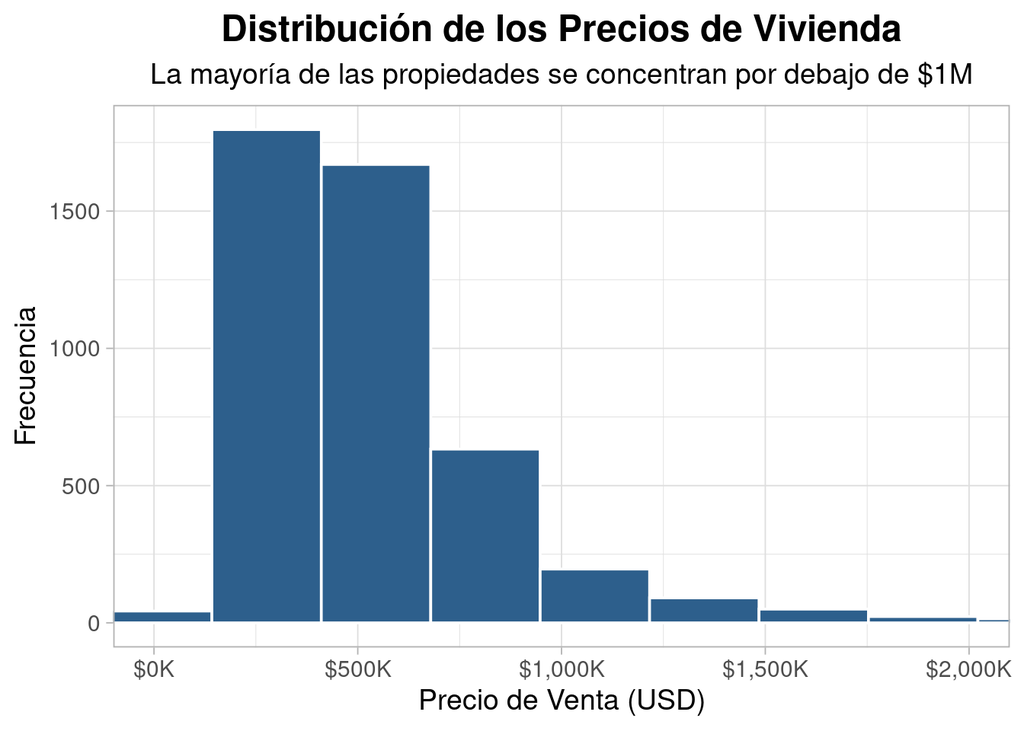

```r
ggplot(df_clean, aes(x = price)) +
  geom_histogram(fill = starry_night_palette[2], color = "white", bins = 100) +
  scale_x_continuous(labels = dollar_format(scale = 1/1000, suffix = "K")) +
  coord_cartesian(xlim = c(0, 2000000)) +
  labs(title = "Distribución de los Precios de Vivienda",
       subtitle = "La mayoría de las propiedades se concentran por debajo de $1M",
       x = "Precio de Venta (USD)",
       y = "Frecuencia")
```

**Análisis:** El precio medio de una vivienda en la muestra es de **$557,626**. Sin embargo, la **mediana** es considerablemente más baja ($465,000), lo que indica, al igual que en el histograma, una distribución **sesgada a la derecha**. Esto significa que la mayoría de las casas tienen un precio relativamente moderado, pero un pequeño número de propiedades de lujo elevan el promedio general.

## 6. Relación entre Características y Precio

### 6.1. Precio vs. Superficie Habitable (`sqft_living`)

La superficie es intuitivamente uno de los factores más importantes en el precio.

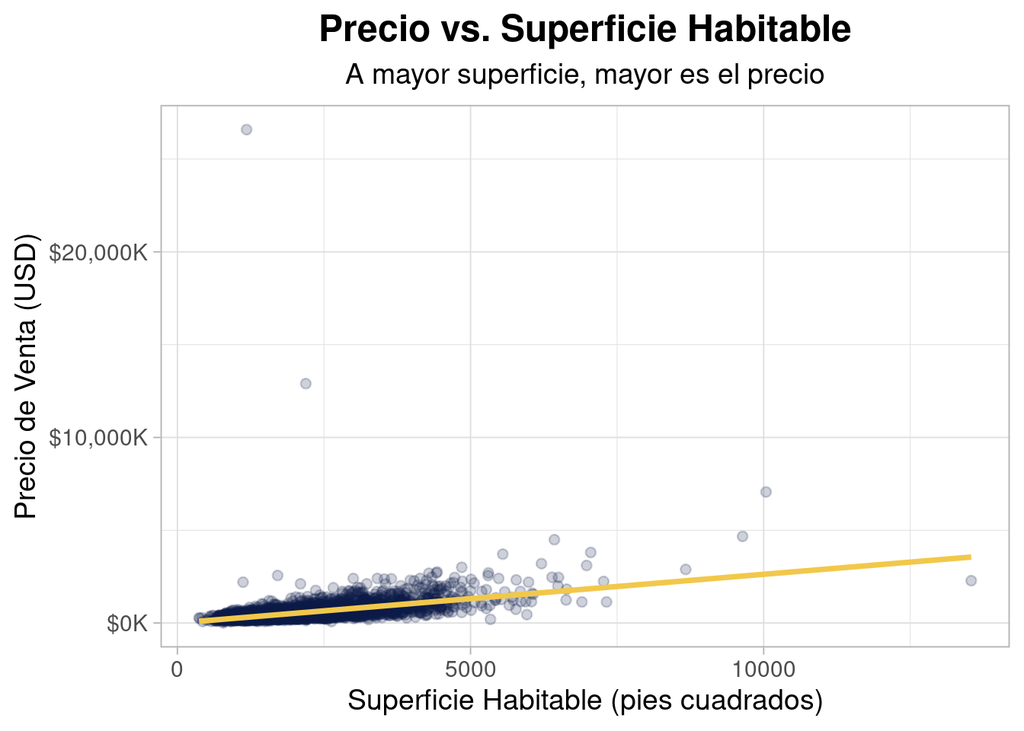

```r
ggplot(df_clean, aes(x = sqft_living, y = price)) +
  geom_point(alpha = 0.2, color = starry_night_palette[1]) +
  geom_smooth(method = "lm", color = starry_night_palette[5], se = FALSE) +
  scale_y_continuous(labels = dollar_format(scale = 1/1000, suffix = "K")) +
  labs(title = "Precio vs. Superficie Habitable",
       subtitle = "A mayor superficie, mayor es el precio",
       x = "Superficie Habitable (pies cuadrados)",
       y = "Precio de Venta (USD)")
```

**Análisis:** El diagrama de dispersión muestra una **clara relación lineal positiva** entre la superficie habitable y el precio. A medida que aumenta el tamaño de la vivienda, su precio tiende a aumentar de manera consistente. La línea de tendencia confirma esta fuerte asociación.

### 6.2. Influencia del Número de Habitaciones

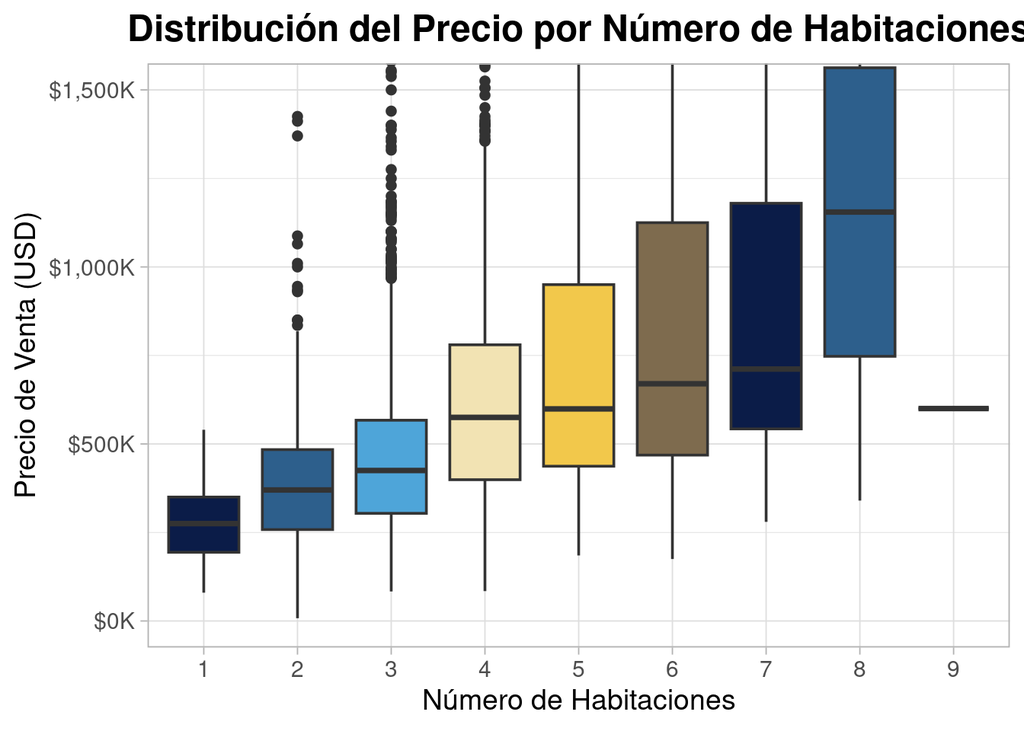

```r
ggplot(df_clean, aes(x = as.factor(bedrooms), y = price, fill = as.factor(bedrooms))) +
  geom_boxplot(show.legend = FALSE) +
  scale_fill_manual(values = rep(starry_night_palette, length.out = length(unique(df_clean$bedrooms)))) +
  scale_y_continuous(labels = dollar_format(scale = 1/1000, suffix = "K")) +
  coord_cartesian(ylim = c(0, 1500000)) +
  labs(title = "Distribución del Precio por Número de Habitaciones",
       x = "Número de Habitaciones",
       y = "Precio de Venta (USD)")
```

### 6.3. Influencia del Estado de Conservación

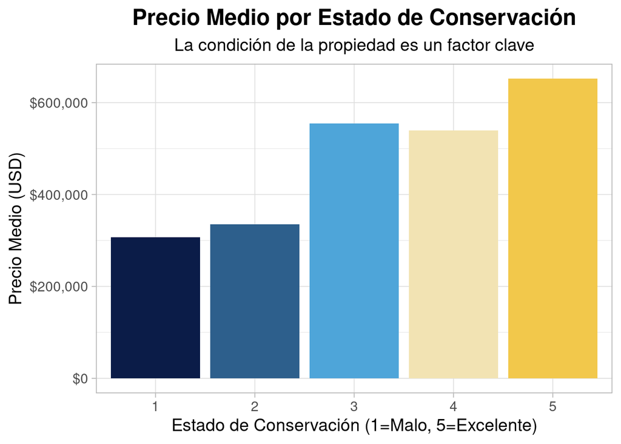

## 7. Análisis Geográfico

### 7.1. Ciudades con Mayor Precio Promedio

Finalmente, se identifican las ciudades donde el mercado inmobiliario es más costoso.

Top 10 Ciudades por Precio Medio de Vivienda (con >50 ventas)

| Ciudad | Precio Medio (USD) | Nº de Ventas |
| --- | --- | --- |
| Mercer Island | 1178638 | 82 |
| Bellevue | 862255 | 281 |
| Sammamish | 702986 | 171 |
| Redmond | 664966 | 234 |
| Kirkland | 651584 | 187 |
| Woodinville | 614912 | 114 |
| Issaquah | 599369 | 186 |
| Seattle | 583968 | 1560 |
| Snoqualmie | 551850 | 69 |
| Kenmore | 454379 | 65 |

# Conclusiones

Este análisis descriptivo del mercado de viviendas en el estado de Washington ha revelado varios patrones determinantes:

En resumen, el precio de una vivienda en este mercado puede ser descrito en gran medida por una combinación de su tamaño, su condición y, sobre todo, su ubicación.